# Use Case: Identify potential area for a new cafe in Melbourne by using residential and industrial data.

The project is designed to apply machine learning to predict the number of cafés in a Melbourne suburb based on two factors, the amount of resident and the number of industries in the area.

The project will run through the process of identifying datasets for predictive learning. Techniques such as API call, data wrangling, feature selection, and machine learning selection will be illustrated during this projects.

```python
import numpy as np
import pandas as pd
import tensorflow as tf
import requests
from sklearn.preprocessing import MinMaxScaler
from tensorflow.keras.models import Sequential
from tensorflow.keras.layers import LSTM, Dense
import matplotlib.pyplot as plt
import seaborn as sns
from sklearn.linear_model import LinearRegression
from sklearn import preprocessing
from sklearn.preprocessing import StandardScaler
from sklearn.preprocessing import LabelEncoder
from sklearn.metrics import mean_squared_error, r2_score
from sklearn.svm import SVR
from sklearn.model_selection import GridSearchCV
from sklearn.ensemble import GradientBoostingRegressor
from sklearn.tree import DecisionTreeRegressor
from sklearn.linear_model import ElasticNet
from sklearn.model_selection import GridSearchCV
from sklearn.metrics import make_scorer, r2_score
import os
import warnings
```

```
2024-04-29 19:50:08.883708: I tensorflow/core/platform/cpu_feature_guard.cc:193] This TensorFlow binary is optimized with oneAPI Deep Neural Network Library (oneDNN) to use the following CPU instructions in performance-critical operations:  SSE4.1 SSE4.2 AVX AVX2 FMA
To enable them in other operations, rebuild TensorFlow with the appropriate compiler flags.
```

# Step 1. Calling API

## API Function for Dwelling dataset and business dataset

```python
def fetch_data(base_url, dataset, api_key, num_records, max_offset,where, offset):
    all_records =[]
    #Maximum number of requests

    while True:
        # Maximum limit check
        if offset > max_offset:
            break

        # Create API request URL

        filters = f'{dataset}/records?&limit={num_records}&offset={offset}&where={where}'
        url = f'{base_url}{filters}&api_key={api_key}'

        try:
            result = requests.get(url, timeout=10)
            result.raise_for_status()
            records = result.json().get('results')
        except requests.exceptions.RequestException as e:
            raise Exception(f'API request failed: {e}')

        if records is None:
            break

        all_records.extend(records)
        if len(records) < num_records:
            break

        # next cycle offset
        offset += num_records

    # Dataframe all data
    df = pd.DataFrame(all_records)
    return df
```

## Creating the DataSet .

#### - API key is obtained from the MOP wensite.

#### - API for dataset is displayed below:

https://data.melbourne.vic.gov.au/api/explore/v2.1/catalog/datasets/development-activity-monitor/records?limit=20  
https://data.melbourne.vic.gov.au/explore/dataset/cafes-and-restaurants-with-seating-capacity/api/?refine.census_year=2022  
https://data.melbourne.vic.gov.au/explore/dataset/employment-by-block-by-clue-industry/api/  
https://data.melbourne.vic.gov.au/explore/dataset/employment-by-block-by-clue-industry/api/

```python
# PERSONLA KEY: eb67c6d708fd15de910be7c7a1e7c7eac64c7c0ad1da6c6f7a8fe928
API_KEY = 'PLEASE USE YOUR PROVIDED KEY'
BASE_URL = "https://data.melbourne.vic.gov.au/api/explore/v2.1/catalog/datasets/"
DATASET_DEVELOPMENT = 'development-activity-monitor'
DATASET_BUS = 'business-establishments-per-block-by-anzsic'
NUM_RECORD = 100
MAX_OFFSET_DEV = 1420
MAX_OFFSET_BUS = 12394
OFFSET = 0
# General select and group_by for Business and Dwelling
WHERE_DEV = ''
WHERE_BUS_2011 = 'census_year%20%3E%202010'
WHERE_BUS_2010 ='census_year%20%3C%202011'
```

```python
# Dwelling dataset
df_dev = fetch_data(BASE_URL, DATASET_DEVELOPMENT, API_KEY, NUM_RECORD, MAX_OFFSET_DEV, WHERE_DEV, OFFSET)
df_dev.shape
```

```
(1433, 42)
```

```python
# Breakdown Business dataset into two due to size
df_2011 = fetch_data(BASE_URL, DATASET_BUS, API_KEY, NUM_RECORD, MAX_OFFSET_BUS, WHERE_BUS_2011, OFFSET)
```

```python
df_2011.shape
```

```
(7279, 23)
```

```python
df_2010 = fetch_data(BASE_URL, DATASET_BUS, API_KEY, NUM_RECORD, MAX_OFFSET_BUS,WHERE_BUS_2010, OFFSET)
df_2010.shape
```

```
(5115, 23)
```

```python
# Merging the business datasets together
df_bus = pd.concat([df_2011,df_2010])
df_bus.shape
```

```
(12394, 23)
```

## Due to the cafe dataset size - aggregate was used to reduce the size of the dataset

```python
def fetch_data_cafe(base_url, api_key,offset,max_offset,num_records):
    all_records =[]
    #Maximum number of requests

    while True:
        # Maximum limit check
        if offset > max_offset:
            break

        # Create API request URL

        url = f'{base_url}&api_key={api_key}'

        try:
            result = requests.get(url, timeout=10)
            result.raise_for_status()
            records = result.json().get('results')
        except requests.exceptions.RequestException as e:
            raise Exception(f'API request failed: {e}')

        if records is None:
            break

        all_records.extend(records)
        if len(records) < num_records:
            break

        # next cycle offset
        offset += num_records

    # Dataframe all data
    df = pd.DataFrame(all_records)
    return df
```

```python
URL_C = 'https://data.melbourne.vic.gov.au/api/explore/v2.1/catalog/datasets/cafes-and-restaurants-with-seating-capacity/records?select=census_year%2C%20clue_small_area%2C%20count(industry_anzsic4_code)%20as%20total&group_by=census_year%2C%20clue_small_area'
API_KEY_C = 'PLEASE USE YOUR PROVIDED KEY'
OFFSET_C = 0
MAX_OFFSET_CAF = 10000
NUM_RECORD_C = 100
```

```python
dfc = fetch_data_cafe(URL_C, API_KEY_C, OFFSET_C,MAX_OFFSET_CAF,NUM_RECORD_C )
dfc.shape
```

```
(27573, 3)
```

# Step 2. Checking the quality of the data

## Need to clean up dataset

The aim of this data set is to extract the number of dwelling in individual clue_small_area for each year.

1. Use data with Status = COMPLETED - To avoild duplicates.
2. Identify required fields
3. Produce the total Number of residential dwelling for individual clue_small_ares for each year.
4. Identify the new dataset field types and adjust.
5. Check data for missing values

```python
df_dev2= df_dev.copy()
```

```python
df_dev.head(2)
```

|  | data_format | development_key | status | year_completed | clue_small_area | clue_block | street_address | property_id | property_id_2 | property_id_3 | ... | hospital_flr | recreation_flr | publicdispaly_flr | community_flr | car_spaces | bike_spaces | town_planning_application | longitude | latitude | geopoint |
| --- | --- | --- | --- | --- | --- | --- | --- | --- | --- | --- | --- | --- | --- | --- | --- | --- | --- | --- | --- | --- | --- |
| 0 | Pre May 16 | X000479 | COMPLETED | 2006 | North Melbourne | 342 | 191-201 Abbotsford Street NORTH MELBOURNE VIC ... | 100023 | None | None | ... | 0 | 0 | 0 | 0 | 0 | 0 | 0 | 144.945030 | -37.802822 | {'lon': 144.9450298, 'lat': -37.80282184} |
| 1 | Pre May 16 | X000459 | COMPLETED | 2005 | North Melbourne | 333 | 218-224 Abbotsford Street NORTH MELBOURNE VIC ... | 100119 | None | None | ... | 0 | 0 | 0 | 0 | 0 | 0 | 0 | 144.945947 | -37.802049 | {'lon': 144.9459475, 'lat': -37.80204879} |

2 rows × 42 columns

```python
#1. Use data with Status = COMPLETED
df_dev = df_dev.loc[df_dev['status'] == 'COMPLETED']
```

```python
#2. Identify required fields
df_dev.iloc[:,[3,4,13,14,15,16,17,18]].head(10)
```

|  | year_completed | clue_small_area | resi_dwellings | studio_dwe | one_bdrm_dwe | two_bdrm_dwe | three_bdrm_dwe | student_apartments |
| --- | --- | --- | --- | --- | --- | --- | --- | --- |
| 0 | 2006 | North Melbourne | 17 | 0 | 0 | 0 | 0 | 0 |
| 1 | 2005 | North Melbourne | 12 | 0 | 0 | 0 | 0 | 0 |
| 2 | 2013 | West Melbourne (Residential) | 3 | 0 | 0 | 0 | 3 | 0 |
| 3 | 2014 | West Melbourne (Residential) | 28 | 0 | 17 | 11 | 0 | 0 |
| 4 | 2007 | North Melbourne | 0 | 0 | 0 | 0 | 0 | 0 |
| 5 | 2002 | Carlton | 14 | 0 | 0 | 0 | 0 | 0 |
| 6 | 2015 | Melbourne (Remainder) | 0 | 0 | 0 | 0 | 0 | 0 |
| 7 | 2009 | West Melbourne (Residential) | 0 | 0 | 0 | 0 | 0 | 0 |
| 8 | 2010 | Melbourne (CBD) | 0 | 0 | 0 | 0 | 0 | 0 |
| 9 | 2006 | Carlton | 0 | 0 | 0 | 0 | 0 | 70 |

```python
#3. Produce the total Number of residential dwelling for individual clue_small_ares for each year.
df_dev['Total'] = df_dev.iloc[:,[13,14,15,16,17,18]].sum(axis=1)
```

```python
#. Identify the new dataset field types and adjust.
df_dev= df_dev.iloc[:,[3,4,42]]
df_dev.dtypes
```

```
year_completed     object
clue_small_area    object
Total               int64
dtype: object
```

```python
# Changing year_completed in Year
df_dev['year_completed']=df_dev['year_completed'].astype(int)
```

```python
df_dev = df_dev.sort_values(by=['year_completed','clue_small_area'])
```

```python
df_dev
```

|  | year_completed | clue_small_area | Total |
| --- | --- | --- | --- |
| 5 | 2002 | Carlton | 14 |
| 521 | 2002 | Carlton | 0 |
| 997 | 2002 | Carlton | 33 |
| 152 | 2002 | Docklands | 109 |
| 625 | 2002 | Docklands | 174 |
| ... | ... | ... | ... |
| 952 | 2024 | Carlton | 232 |
| 349 | 2024 | Melbourne (CBD) | 521 |
| 351 | 2024 | Melbourne (Remainder) | 0 |
| 1411 | 2024 | North Melbourne | 138 |
| 350 | 2024 | West Melbourne (Residential) | 0 |

1038 rows × 3 columns

```python
df_dev = df_dev.groupby(['year_completed','clue_small_area']).agg({'Total':'sum'})
```

```python
df_dev = df_dev.reset_index()
```

## Working the second dataset - business

1. Check dataset for null values
2. Group data together per year, and individual
3. Identify unecessary fields
4. Check the data types

```python
df_bus2 = df_bus.copy()
```

```python
#1. Check dataset for null values
df_bus.isna().sum()
```

```
census_year                                       0
block_id                                          0
clue_small_area                                   0
accommodation_and_food_services                   0
administrative_and_support_services               0
agriculture_forestry_and_fishing                  0
arts_and_recreation_services                      0
construction                                      0
education_and_training                            0
electricity_gas_water_and_waste_services          0
financial_and_insurance_services                  0
health_care_and_social_assistance                 0
information_media_and_telecommunications          0
manufacturing                                     0
mining                                            0
other_services                                    0
professional_scientific_and_technical_services    0
public_administration_and_safety                  0
rental_hiring_and_real_estate_services            0
retail_trade                                      0
transport_postal_and_warehousing                  0
wholesale_trade                                   0
total_establishments_in_block                     0
dtype: int64
```

```python
#2. Group data together per year, and individual
df_bus = df_bus.groupby(['census_year','clue_small_area']).sum()
```

```python
#3. Identify unecessary fields
# The block_id is not required
df_bus.drop(columns =['block_id'], inplace=True)
df_bus = df_bus.reset_index()
```

## Merging Dwelling and Business data sets together.

1. Need to make columns census_year in dwelling dataset
2. Need to ensure census_year and clue_small_area has the same type
3. merge the two dataset

```python
#1. Rename year_completed to census_year from dwelling dataset
df_dev.rename(columns={'year_completed':'census_year'},inplace=True)
```

```python
df_dev.dtypes
```

```
census_year         int64
clue_small_area    object
Total               int64
dtype: object
```

```python
df_bus.dtypes
```

```
census_year                                       object
clue_small_area                                   object
accommodation_and_food_services                    int64
administrative_and_support_services                int64
agriculture_forestry_and_fishing                   int64
arts_and_recreation_services                       int64
construction                                       int64
education_and_training                             int64
electricity_gas_water_and_waste_services           int64
financial_and_insurance_services                   int64
health_care_and_social_assistance                  int64
information_media_and_telecommunications           int64
manufacturing                                      int64
mining                                             int64
other_services                                     int64
professional_scientific_and_technical_services     int64
public_administration_and_safety                   int64
rental_hiring_and_real_estate_services             int64
retail_trade                                       int64
transport_postal_and_warehousing                   int64
wholesale_trade                                    int64
total_establishments_in_block                      int64
dtype: object
```

```python
df_bus['census_year']=df_bus['census_year'].astype(int)
```

```python
df_bus = df_bus.sort_values(by=['census_year','clue_small_area'])
```

```python
df_bus.shape
```

```
(294, 22)
```

```python
df_dev.shape
```

```
(225, 3)
```

```python
#2. Merge data on year and clue_small_area
data_merged = pd.merge(df_bus, df_dev,on=['census_year','clue_small_area'],how='inner')
data_merged.shape
```

```
(210, 23)
```

```python
data_merged.head(2)
```

|  | census_year | clue_small_area | accommodation_and_food_services | administrative_and_support_services | agriculture_forestry_and_fishing | arts_and_recreation_services | construction | education_and_training | electricity_gas_water_and_waste_services | financial_and_insurance_services | ... | mining | other_services | professional_scientific_and_technical_services | public_administration_and_safety | rental_hiring_and_real_estate_services | retail_trade | transport_postal_and_warehousing | wholesale_trade | total_establishments_in_block | Total |
| --- | --- | --- | --- | --- | --- | --- | --- | --- | --- | --- | --- | --- | --- | --- | --- | --- | --- | --- | --- | --- | --- |
| 0 | 2002 | Carlton | 190 | 40 | 0 | 31 | 13 | 61 | 13 | 41 | ... | 0 | 146 | 143 | 13 | 15 | 166 | 10 | 24 | 1069 | 47 |
| 1 | 2002 | Docklands | 23 | 6 | 1 | 9 | 4 | 1 | 6 | 1 | ... | 0 | 14 | 7 | 7 | 4 | 11 | 36 | 3 | 147 | 850 |

2 rows × 23 columns

```python
data_merged['census_year'].unique()
```

```
array([2002, 2003, 2004, 2005, 2006, 2007, 2008, 2009, 2010, 2011, 2012,
       2013, 2014, 2015, 2016, 2017, 2018, 2019, 2020, 2021, 2022])
```

```python
data_merged['clue_small_area'].unique()
```

```
array(['Carlton', 'Docklands', 'East Melbourne', 'Kensington',
       'Melbourne (CBD)', 'North Melbourne', 'Parkville',
       'Port Melbourne', 'Southbank', 'West Melbourne (Industrial)',
       'West Melbourne (Residential)', 'South Yarra',
       'Melbourne (Remainder)'], dtype=object)
```

## Checking Cafe dataset and merging with data_merged

1. Check for duplicates and null values
2. Change the name of column total to Total_cafe
3. merge the two dataset
4. Drop All row containing null values

```python
dfc2 =dfc.copy()
```

```python
#1. Check for duplicates
dfc.duplicated()
```

```
0        False
1        False
2        False
3        False
4        False
         ...
27568     True
27569     True
27570     True
27571     True
27572     True
Length: 27573, dtype: bool
```

```python
dfc = dfc.drop_duplicates()
```

```python
dfc.shape
```

```
(273, 3)
```

```python
data_merged['clue_small_area'].unique()
```

```
array(['Carlton', 'Docklands', 'East Melbourne', 'Kensington',
       'Melbourne (CBD)', 'North Melbourne', 'Parkville',
       'Port Melbourne', 'Southbank', 'West Melbourne (Industrial)',
       'West Melbourne (Residential)', 'South Yarra',
       'Melbourne (Remainder)'], dtype=object)
```

```python
dfc['clue_small_area'].unique()
```

```
array(['Carlton', 'Docklands', 'East Melbourne', 'Kensington',
       'Melbourne (CBD)', 'Melbourne (Remainder)', 'North Melbourne',
       'Parkville', 'Port Melbourne', 'South Yarra', 'Southbank',
       'West Melbourne (Industrial)', 'West Melbourne (Residential)'],
      dtype=object)
```

```python
dfc['census_year'].unique()
```

```
array(['2002-01-01T00:00:00+00:00', '2003-01-01T00:00:00+00:00',
       '2004-01-01T00:00:00+00:00', '2005-01-01T00:00:00+00:00',
       '2006-01-01T00:00:00+00:00', '2007-01-01T00:00:00+00:00',
       '2008-01-01T00:00:00+00:00', '2009-01-01T00:00:00+00:00',
       '2010-01-01T00:00:00+00:00', '2011-01-01T00:00:00+00:00',
       '2012-01-01T00:00:00+00:00', '2013-01-01T00:00:00+00:00',
       '2014-01-01T00:00:00+00:00', '2015-01-01T00:00:00+00:00',
       '2016-01-01T00:00:00+00:00', '2017-01-01T00:00:00+00:00',
       '2018-01-01T00:00:00+00:00', '2019-01-01T00:00:00+00:00',
       '2020-01-01T00:00:00+00:00', '2021-01-01T00:00:00+00:00',
       '2022-01-01T00:00:00+00:00'], dtype=object)
```

```python
dfc.isna().sum()
```

```
census_year        0
clue_small_area    0
total              0
dtype: int64
```

```python
#3. Changing the column name from total to total cafe
dfc.rename(columns={'total':'Total_cafe'},inplace=True)
```

```python
dfc.dtypes
```

```
census_year        object
clue_small_area    object
Total_cafe          int64
dtype: object
```

```python
dfc['census_year'] = pd.to_datetime(dfc['census_year'] )
dfc['census_year'] = dfc['census_year'].dt.year.astype(int)
```

```python
dfc = dfc.sort_values(by=['census_year','clue_small_area'])
```

```python
dfc.dtypes
```

```
census_year         int64
clue_small_area    object
Total_cafe          int64
dtype: object
```

```python
#2. Merging the dataset on the cafe dataset as no 'City of Melbourne (total)' present
data = pd.merge( data_merged, dfc, how='inner', on=['census_year','clue_small_area'])

data.shape
```

```
(210, 24)
```

```python
data
```

|  | census_year | clue_small_area | accommodation_and_food_services | administrative_and_support_services | agriculture_forestry_and_fishing | arts_and_recreation_services | construction | education_and_training | electricity_gas_water_and_waste_services | financial_and_insurance_services | ... | other_services | professional_scientific_and_technical_services | public_administration_and_safety | rental_hiring_and_real_estate_services | retail_trade | transport_postal_and_warehousing | wholesale_trade | total_establishments_in_block | Total | Total_cafe |
| --- | --- | --- | --- | --- | --- | --- | --- | --- | --- | --- | --- | --- | --- | --- | --- | --- | --- | --- | --- | --- | --- |
| 0 | 2002 | Carlton | 190 | 40 | 0 | 31 | 13 | 61 | 13 | 41 | ... | 146 | 143 | 13 | 15 | 166 | 10 | 24 | 1069 | 47 | 241 |
| 1 | 2002 | Docklands | 23 | 6 | 1 | 9 | 4 | 1 | 6 | 1 | ... | 14 | 7 | 7 | 4 | 11 | 36 | 3 | 147 | 850 | 24 |
| 2 | 2002 | East Melbourne | 54 | 22 | 0 | 42 | 4 | 12 | 8 | 17 | ... | 40 | 70 | 14 | 5 | 16 | 6 | 7 | 488 | 78 | 39 |
| 3 | 2002 | Kensington | 12 | 1 | 0 | 60 | 2 | 2 | 4 | 2 | ... | 8 | 6 | 3 | 2 | 7 | 5 | 23 | 169 | 81 | 8 |
| 4 | 2002 | Melbourne (CBD) | 993 | 489 | 7 | 92 | 68 | 143 | 53 | 620 | ... | 605 | 1343 | 161 | 148 | 1317 | 129 | 128 | 7164 | 1452 | 1072 |
| ... | ... | ... | ... | ... | ... | ... | ... | ... | ... | ... | ... | ... | ... | ... | ... | ... | ... | ... | ... | ... | ... |
| 205 | 2022 | Melbourne (CBD) | 1591 | 254 | 4 | 139 | 118 | 310 | 69 | 592 | ... | 809 | 1439 | 178 | 208 | 1112 | 74 | 91 | 7644 | 724 | 1608 |
| 206 | 2022 | North Melbourne | 132 | 30 | 2 | 48 | 20 | 31 | 24 | 12 | ... | 119 | 118 | 9 | 18 | 77 | 14 | 37 | 822 | 16 | 148 |
| 207 | 2022 | Port Melbourne | 17 | 21 | 1 | 12 | 61 | 9 | 10 | 5 | ... | 15 | 64 | 17 | 18 | 25 | 31 | 49 | 462 | 0 | 28 |
| 208 | 2022 | Southbank | 220 | 24 | 2 | 56 | 24 | 16 | 26 | 29 | ... | 36 | 95 | 9 | 26 | 217 | 11 | 14 | 865 | 1994 | 223 |
| 209 | 2022 | West Melbourne (Residential) | 53 | 7 | 0 | 22 | 15 | 17 | 8 | 6 | ... | 35 | 74 | 5 | 6 | 31 | 7 | 15 | 341 | 704 | 69 |

210 rows × 24 columns

```python
data.isna().sum()
```

```
census_year                                       0
clue_small_area                                   0
accommodation_and_food_services                   0
administrative_and_support_services               0
agriculture_forestry_and_fishing                  0
arts_and_recreation_services                      0
construction                                      0
education_and_training                            0
electricity_gas_water_and_waste_services          0
financial_and_insurance_services                  0
health_care_and_social_assistance                 0
information_media_and_telecommunications          0
manufacturing                                     0
mining                                            0
other_services                                    0
professional_scientific_and_technical_services    0
public_administration_and_safety                  0
rental_hiring_and_real_estate_services            0
retail_trade                                      0
transport_postal_and_warehousing                  0
wholesale_trade                                   0
total_establishments_in_block                     0
Total                                             0
Total_cafe                                        0
dtype: int64
```

# Step 3. Creating a target for the dataset.

- The new feature is called New_Cafe: New_Cafe is the difference of cafe number between the next year and the current year.
- Hence, for 2002, we are returning the number of cafe that will open in 2003 based on the features of 2002.

```python
def new_cafe_feature(df):
    for city in df['clue_small_area'].unique():
        diff = df.loc[df['clue_small_area'] == city, 'Total_cafe'].diff()

        # Drop the first value of the difference
        diff = diff.iloc[1:]
        # Append a value of 0 to the end of the difference series
        diff = pd.concat([diff, pd.Series([0], index=[diff.index[-1] + 1])])

        # Replacing negative or NaN differences with 0
        diff[diff < 0] = 0
        diff.fillna(0, inplace=True)


        # Assigning new cafe values to the corresponding rows in the original DataFrame

        df.loc[df['clue_small_area'] == city, 'New_Cafe'] = diff.values

    return df
```

```python
dataT = data.copy()
dataT['New_Cafe']=0
```

```python
dataT = new_cafe_feature(dataT)
```

```python
data['New_Cafe'] = dataT['New_Cafe']
```

```python
data.head(20)
```

|  | census_year | clue_small_area | accommodation_and_food_services | administrative_and_support_services | agriculture_forestry_and_fishing | arts_and_recreation_services | construction | education_and_training | electricity_gas_water_and_waste_services | financial_and_insurance_services | ... | professional_scientific_and_technical_services | public_administration_and_safety | rental_hiring_and_real_estate_services | retail_trade | transport_postal_and_warehousing | wholesale_trade | total_establishments_in_block | Total | Total_cafe | New_Cafe |
| --- | --- | --- | --- | --- | --- | --- | --- | --- | --- | --- | --- | --- | --- | --- | --- | --- | --- | --- | --- | --- | --- |
| 0 | 2002 | Carlton | 190 | 40 | 0 | 31 | 13 | 61 | 13 | 41 | ... | 143 | 13 | 15 | 166 | 10 | 24 | 1069 | 47 | 241 | 33 |
| 1 | 2002 | Docklands | 23 | 6 | 1 | 9 | 4 | 1 | 6 | 1 | ... | 7 | 7 | 4 | 11 | 36 | 3 | 147 | 850 | 24 | 26 |
| 2 | 2002 | East Melbourne | 54 | 22 | 0 | 42 | 4 | 12 | 8 | 17 | ... | 70 | 14 | 5 | 16 | 6 | 7 | 488 | 78 | 39 | 5 |
| 3 | 2002 | Kensington | 12 | 1 | 0 | 60 | 2 | 2 | 4 | 2 | ... | 6 | 3 | 2 | 7 | 5 | 23 | 169 | 81 | 8 | 0 |
| 4 | 2002 | Melbourne (CBD) | 993 | 489 | 7 | 92 | 68 | 143 | 53 | 620 | ... | 1343 | 161 | 148 | 1317 | 129 | 128 | 7164 | 1452 | 1072 | 0 |
| 5 | 2002 | North Melbourne | 84 | 32 | 2 | 37 | 20 | 14 | 22 | 22 | ... | 111 | 7 | 15 | 93 | 43 | 75 | 832 | 89 | 79 | 20 |
| 6 | 2002 | Parkville | 51 | 3 | 0 | 24 | 0 | 7 | 7 | 5 | ... | 6 | 4 | 1 | 19 | 4 | 3 | 206 | 42 | 30 | 4 |
| 7 | 2002 | Port Melbourne | 4 | 6 | 0 | 9 | 11 | 2 | 5 | 2 | ... | 21 | 5 | 3 | 8 | 21 | 35 | 180 | 0 | 3 | 0 |
| 8 | 2002 | Southbank | 91 | 19 | 2 | 38 | 8 | 10 | 21 | 23 | ... | 91 | 10 | 17 | 96 | 16 | 21 | 581 | 897 | 100 | 0 |
| 9 | 2002 | West Melbourne (Industrial) | 10 | 4 | 1 | 5 | 6 | 0 | 8 | 1 | ... | 6 | 1 | 11 | 9 | 89 | 197 | 376 | 0 | 13 | 0 |
| 10 | 2002 | West Melbourne (Residential) | 44 | 31 | 0 | 19 | 11 | 9 | 9 | 15 | ... | 71 | 8 | 4 | 48 | 22 | 54 | 480 | 31 | 50 | 5 |
| 11 | 2003 | Carlton | 202 | 38 | 0 | 36 | 12 | 68 | 15 | 44 | ... | 158 | 17 | 22 | 168 | 11 | 28 | 1140 | 754 | 274 | 0 |
| 12 | 2003 | Docklands | 36 | 5 | 1 | 9 | 4 | 2 | 6 | 3 | ... | 6 | 7 | 2 | 16 | 18 | 3 | 145 | 791 | 50 | 0 |
| 13 | 2003 | Kensington | 12 | 1 | 0 | 60 | 2 | 2 | 4 | 2 | ... | 6 | 3 | 2 | 7 | 5 | 23 | 169 | 1332 | 8 | 3 |
| 14 | 2003 | Melbourne (CBD) | 993 | 489 | 7 | 92 | 68 | 143 | 53 | 620 | ... | 1343 | 161 | 148 | 1317 | 129 | 128 | 7164 | 493 | 1072 | 150 |
| 15 | 2003 | North Melbourne | 90 | 33 | 1 | 31 | 19 | 15 | 21 | 23 | ... | 142 | 4 | 19 | 95 | 38 | 63 | 867 | 158 | 99 | 0 |
| 16 | 2003 | Port Melbourne | 4 | 6 | 0 | 9 | 11 | 2 | 5 | 2 | ... | 21 | 5 | 3 | 8 | 21 | 35 | 180 | 0 | 3 | 8 |
| 17 | 2003 | South Yarra | 15 | 1 | 0 | 4 | 0 | 12 | 6 | 0 | ... | 2 | 2 | 0 | 10 | 0 | 0 | 69 | 24 | 10 | 6 |
| 18 | 2003 | Southbank | 91 | 19 | 2 | 38 | 8 | 10 | 21 | 23 | ... | 91 | 10 | 17 | 96 | 16 | 21 | 581 | 182 | 100 | 7 |
| 19 | 2003 | West Melbourne (Residential) | 48 | 26 | 0 | 21 | 9 | 8 | 8 | 19 | ... | 89 | 9 | 7 | 52 | 23 | 45 | 509 | 95 | 55 | 0 |

20 rows × 25 columns

# Step 3. Machine learning and Deep learning.

1. Find the best suburb to work with
2. Produce the different machine learning and deep learning
3. Use best prediction.

```python
data['clue_small_area'].unique()
```

```
array(['Carlton', 'Docklands', 'East Melbourne', 'Kensington',
       'Melbourne (CBD)', 'North Melbourne', 'Parkville',
       'Port Melbourne', 'Southbank', 'West Melbourne (Industrial)',
       'West Melbourne (Residential)', 'South Yarra',
       'Melbourne (Remainder)'], dtype=object)
```

```python
def heat_map(data,name):
    '''
        - function is used to return a dataset where the correlation between Total_cafe and features are greater than 0.
        - The function also plots a heatmap of the original.
    '''
    correlation_matrix = data.loc[data['clue_small_area'] == name, :].iloc[:, 2:].corr().round(1)
    positive_correlation_features = correlation_matrix.loc['Total_cafe'] > 0.1 #Need to change from >-0.1 to >=0

    positive_corr_feature_names = positive_correlation_features[positive_correlation_features].index.tolist()


    sns.heatmap(data.loc[data['clue_small_area']==name,:].iloc[:,2:].corr().round(1), annot=True, cmap='BrBG', fmt=".0f", linewidths=.4)
    plt.show()

    filtered_data = data.loc[data['clue_small_area'] == name, ['census_year'] + positive_corr_feature_names]

    return filtered_data

    #return data_r
```

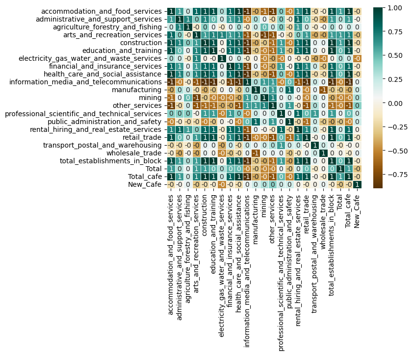

```
(20, 16)
```

```python
Southbank =heat_map(data,'Southbank')
Southbank.shape
```

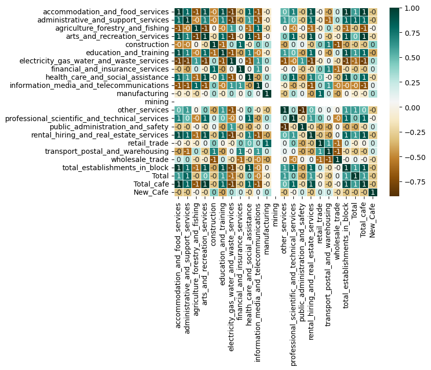

```
(15, 12)
```

```python
Parkville =heat_map(data,'Parkville')
Parkville.shape
```

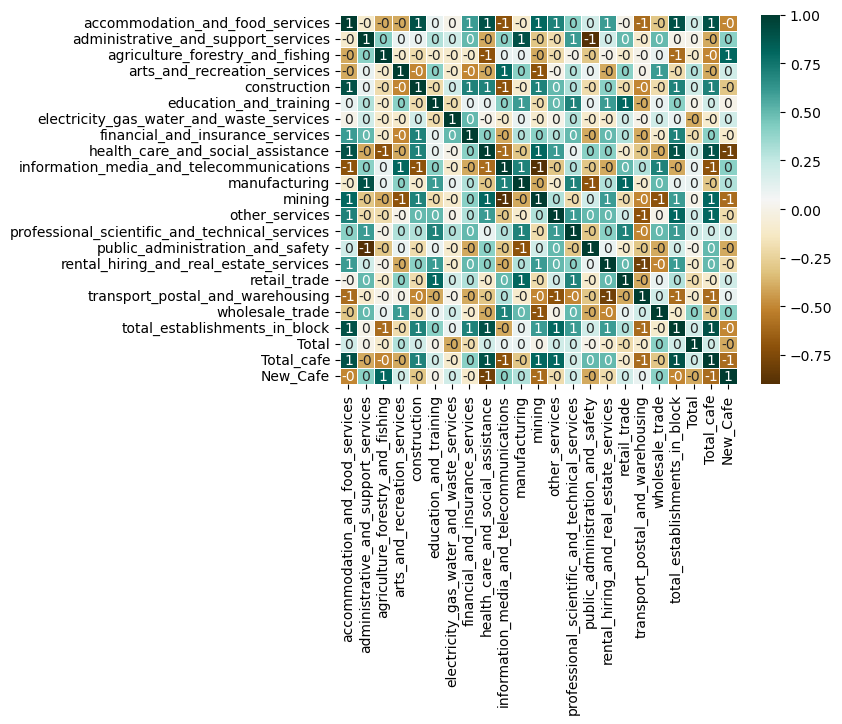

```
(13, 14)
```

```python
East_Melbourne =heat_map(data,'East Melbourne')
East_Melbourne.shape
```

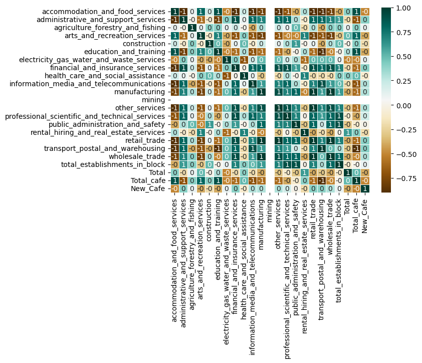

```
(21, 10)
```

```python
Carlton =heat_map(data,'Carlton')
Carlton.shape
```

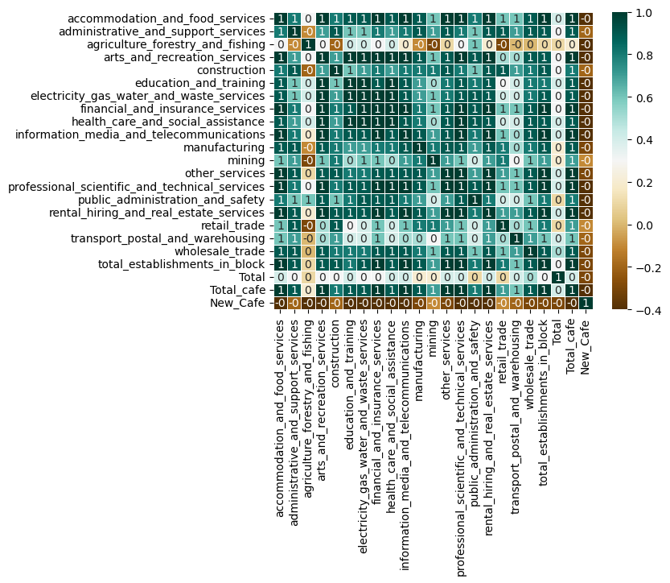

```
(21, 2)
```

```python
Docklands =heat_map(data,'Docklands')
Docklands.shape
```

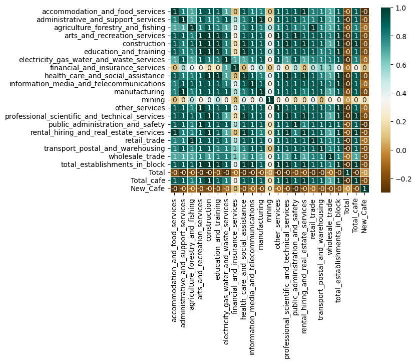

```
(18, 3)
```

```python
Kensington=heat_map(data,'Kensington')
Kensington.shape
```

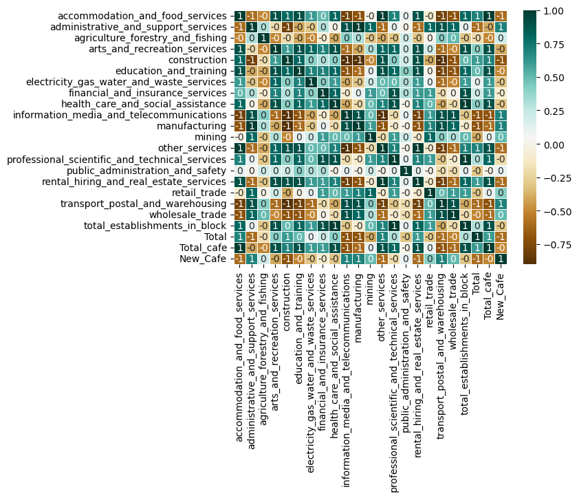

```
(21, 14)
```

```python
Melbourne = heat_map(data,'Melbourne (CBD)')
Melbourne.shape
```

```python
def model_call(df):
    warnings.filterwarnings("ignore")
    feature = df.loc[(df['census_year']<2018),:].drop(columns=['Total_cafe'])
    target = df.loc[(df['census_year']< 2018),['census_year','Total_cafe']]
    # Encoding the Clue Small Area
    le = LabelEncoder()

    X_train = feature.loc[(feature['census_year']<2012),:].values
    y_train = target.loc[(target['census_year']<2012),['Total_cafe']].values

    X_test = feature.loc[(feature['census_year']>2011),:].values
    y_test = target.loc[(target['census_year']>2011),['Total_cafe']].values

    X_train = X_train.reshape((X_train.shape[0], 1, X_train.shape[1]))
    X_test = X_test.reshape((X_test.shape[0], 1, X_test.shape[1]))
    y_train = y_train.reshape((y_train.shape[0], 1, y_train.shape[1]))

    #print(feature.head(10))
    #print(target.shape)
    #print(X_train.shape)
    #print(y_train.shape)
    model = Sequential()

    model.add(LSTM(500, activation='linear', return_sequences=True, input_shape=(X_train.shape[1], X_train.shape[2])))
    model.add(LSTM(units=200, activation='linear', return_sequences=True))
    model.add(LSTM(units=50, activation='linear', return_sequences=True))
    model.add(LSTM(units=20, activation='relu', return_sequences=True))
    model.add(Dense(100,activation = 'relu'))
    model.add(Dense(units=1,activation='linear'))


    model.compile(optimizer='adam', loss='mse')

    model.fit(X_train, y_train, epochs=50, batch_size=2, validation_data=(X_test, y_test), verbose=2)

    loss = model.evaluate(X_test, y_test, verbose=0)
    print('Test Loss:', loss)

    # Make predictions
    predictions = model.predict(X_test)



    # Print predictions
    print('Predictions:', predictions)
    print('Acutal: ', y_test)
```

```python
model_call(Carlton)
```

```
5/5 - 3s - loss: 92130.4062 - val_loss: 131590.1406 - 3s/epoch - 523ms/step
5/5 - 0s - loss: 82809.6406 - val_loss: 119255.3125 - 50ms/epoch - 10ms/step
5/5 - 0s - loss: 66175.0703 - val_loss: 97206.8984 - 47ms/epoch - 9ms/step
5/5 - 0s - loss: 41232.4766 - val_loss: 69565.8203 - 47ms/epoch - 9ms/step
5/5 - 0s - loss: 17434.1523 - val_loss: 38011.2148 - 48ms/epoch - 10ms/step
5/5 - 0s - loss: 3167.1233 - val_loss: 23564.8750 - 47ms/epoch - 9ms/step
5/5 - 0s - loss: 29580.4492 - val_loss: 98978.2109 - 49ms/epoch - 10ms/step
5/5 - 0s - loss: 38378.3555 - val_loss: 71238.1953 - 45ms/epoch - 9ms/step
5/5 - 0s - loss: 13184.7734 - val_loss: 43765.0781 - 50ms/epoch - 10ms/step
5/5 - 0s - loss: 1856.1371 - val_loss: 33761.7461 - 50ms/epoch - 10ms/step
5/5 - 0s - loss: 7211.7061 - val_loss: 47415.6445 - 50ms/epoch - 10ms/step
5/5 - 0s - loss: 12802.8086 - val_loss: 16207.5820 - 50ms/epoch - 10ms/step
5/5 - 0s - loss: 1234.0785 - val_loss: 23964.2715 - 51ms/epoch - 10ms/step
5/5 - 0s - loss: 856.2155 - val_loss: 26790.5059 - 52ms/epoch - 10ms/step
5/5 - 0s - loss: 888.8883 - val_loss: 24969.9609 - 54ms/epoch - 11ms/step
5/5 - 0s - loss: 836.3334 - val_loss: 21498.3750 - 48ms/epoch - 10ms/step
5/5 - 0s - loss: 789.1815 - val_loss: 20426.7012 - 47ms/epoch - 9ms/step
5/5 - 0s - loss: 756.6622 - val_loss: 20997.8887 - 47ms/epoch - 9ms/step
5/5 - 0s - loss: 819.2340 - val_loss: 22691.3574 - 49ms/epoch - 10ms/step
5/5 - 0s - loss: 770.2435 - val_loss: 22155.9355 - 50ms/epoch - 10ms/step
5/5 - 0s - loss: 713.7163 - val_loss: 21209.9785 - 52ms/epoch - 10ms/step
5/5 - 0s - loss: 700.0760 - val_loss: 21078.1602 - 108ms/epoch - 22ms/step
5/5 - 0s - loss: 706.4288 - val_loss: 21138.2246 - 53ms/epoch - 11ms/step
5/5 - 0s - loss: 693.4318 - val_loss: 21535.6973 - 49ms/epoch - 10ms/step
5/5 - 0s - loss: 673.9183 - val_loss: 21922.9551 - 45ms/epoch - 9ms/step
5/5 - 0s - loss: 721.9196 - val_loss: 21640.0312 - 47ms/epoch - 9ms/step
5/5 - 0s - loss: 697.0109 - val_loss: 21728.4668 - 49ms/epoch - 10ms/step
5/5 - 0s - loss: 695.9093 - val_loss: 21398.5254 - 44ms/epoch - 9ms/step
5/5 - 0s - loss: 755.3447 - val_loss: 20714.0254 - 49ms/epoch - 10ms/step
5/5 - 0s - loss: 721.2034 - val_loss: 21089.5488 - 48ms/epoch - 10ms/step
5/5 - 0s - loss: 861.3299 - val_loss: 22893.9824 - 52ms/epoch - 10ms/step
5/5 - 0s - loss: 736.0726 - val_loss: 21730.4512 - 52ms/epoch - 10ms/step
5/5 - 0s - loss: 746.7464 - val_loss: 20668.6582 - 49ms/epoch - 10ms/step
5/5 - 0s - loss: 703.7543 - val_loss: 20972.4473 - 52ms/epoch - 10ms/step
5/5 - 0s - loss: 822.5092 - val_loss: 22938.8730 - 46ms/epoch - 9ms/step
5/5 - 0s - loss: 731.6822 - val_loss: 21484.3730 - 47ms/epoch - 9ms/step
5/5 - 0s - loss: 733.8942 - val_loss: 20443.9941 - 51ms/epoch - 10ms/step
5/5 - 0s - loss: 672.4227 - val_loss: 21692.1094 - 50ms/epoch - 10ms/step
5/5 - 0s - loss: 627.7800 - val_loss: 22379.3184 - 47ms/epoch - 9ms/step
5/5 - 0s - loss: 673.8151 - val_loss: 22356.0371 - 50ms/epoch - 10ms/step
```

[output cut: 13 more lines]

```
 [[303.6626 ]]

 [[ 53.31504]]

 [[304.99365]]

 [[308.03964]]

 [[263.55054]]]
Acutal:  [[346]
 [346]
 [363]
 [363]
 [399]
 [399]]
```

```python
def suburb_data(df,name):
    X_train = df.loc[(df['census_year']<2013),:].drop(columns=['census_year','Total_cafe'])
    y_train = df.loc[(df['census_year']<2013),['Total_cafe']].values

    X_test= df.loc[(df['census_year']>2012)&(df['census_year']<2019),:].drop(columns=['census_year','Total_cafe'])
    y_test = df.loc[(df['census_year']>2012)&(df['census_year']<2019),['Total_cafe']].values

    pred = df.loc[(df['census_year']==2019),:].drop(columns=['census_year','Total_cafe'])

    return X_train, y_train,X_test,y_test,pred,name
```

```python
def model_svr(parameter, X_train, X_test, y_train, y_test, pred, name):
    warnings.filterwarnings("ignore")
    model = SVR(kernel =parameter)
    model.fit(X_train, y_train)

    y_pred = model.predict(X_test)

    mse =mean_squared_error(y_test, y_pred)
    r2 = r2_score(y_test,y_pred)
    print('Mean Suqared Error:',mse)
    print('R-squared',r2)

    value = model.predict(pred)
    if value <= 0:
        value = 0
    else:
        value = value.astype(int)
    print(f'The predicted total number of cafe in {name} is {value}')
    plt.scatter(range(len(y_test)), y_test, color ='blue', label='Actual')
    plt.scatter(range(len(y_pred)), y_pred, color= 'red', label ='Predicted')
    plt.xticks(range(len(y_test)),[2013,2014,2015,2016,2017,2018])
    plt.legend()
    plt.show()
```

```python
def svr_parameters(xtrain, ytrain):
    param_grid = {'C': np.logspace(-3, 3, 3),
              'gamma': np.logspace(-4, 0, 5),
              'kernel': ['rbf', 'linear']}
    MSE = make_scorer(r2_score, greater_is_better=True)
    # Initialize GridSearchCV
    warnings.filterwarnings("ignore")
    grid = GridSearchCV(SVR(), param_grid, scoring=MSE, n_jobs=-1)
    warnings.filterwarnings("ignore")
    # Fit the model for grid search

    grid.fit(xtrain, ytrain)


    # Print the best hyperparameters found

    print("Best Parameters:", grid.best_params_)

    print('Best score:', grid.best_score_)

    print('Best scorer:', grid.scorer_)
```

```python
def elasticnet_parameters(X_train, C_train):
    # Parameter grid for Elastic Net
    elasticnet_param_grid = {
        'alpha': np.logspace(-3, 3, 7),  # Regularization strength
        'l1_ratio': np.linspace(0.1, 0.9, 6)  # Balance between L1 and L2 regularization
    }

    # Create an R² scorer
    r2_scorer = make_scorer(r2_score, greater_is_better=True)

    # Initialize GridSearchCV for Elastic Net
    warnings.filterwarnings("ignore")
    elasticnet_grid = GridSearchCV(ElasticNet(), elasticnet_param_grid, cv=5, scoring=r2_scorer, n_jobs=-1, verbose=3)

    # Fit the model for grid search
    elasticnet_grid.fit(X_train, C_train)  # Replace with your training data

    # Print the best hyperparameters found
    print("Best Parameters for Elastic Net:", elasticnet_grid.best_params_)

    # Display the best R² score achieved by the best model during cross-validation
    print("Best score for Elastic Net:", elasticnet_grid.best_score_)
```

```python
def model_svr_best(c,gamma,parameter, X_train, X_test, y_train, y_test, pred, name):
    '''
        The function takes in the hyper parameter for SVR Net model.
        The function returns a graph of predicted value and actual value.

    '''
    warnings.filterwarnings("ignore")
    model = SVR(C=c, gamma= gamma,kernel =parameter)
    model.fit(X_train, y_train)

    y_pred = model.predict(X_test)

    mse =mean_squared_error(y_test, y_pred)
    r2 = r2_score(y_test,y_pred)
    print('Mean Suqared Error:',mse)
    print('R-squared',r2)

    value_2022 = model.predict(pred)
    if value_2022 < 0:
        value_2022 = 0
    else:
        value_2022 = value_2022.astype(int)
    print(f'The predicted number of new cafe in {name} is {value_2022}')
    plt.scatter(range(len(y_test)), y_test, color ='blue', label='Actual')
    plt.scatter(range(len(y_pred)), y_pred, color= 'red', label ='Predicted')
    plt.legend()
    plt.show()
```

```python
def model_elastic_best(alpha,l1_ratio, X_train, X_test, y_train, y_test, pred, name):
    '''
        The function takes in the hyper parameter for Elastic Net model.
        The function returns a graph of predicted value and actual value.

    '''
    warnings.filterwarnings("ignore")
    model = ElasticNet(alpha =alpha, l1_ratio = l1_ratio)
    model.fit(X_train, y_train)

    y_pred = model.predict(X_test)

    mse =mean_squared_error(y_test, y_pred)
    r2 = r2_score(y_test,y_pred)
    print('Mean Suqared Error:',mse)
    print('R-squared',r2)

    value_2022 = model.predict(pred)
    if value_2022 < 0:
        value_2022 = 0
    else:
        value_2022 = value_2022.astype(int)
    print(f'The predicted number of new cafe in {name} is {value_2022}')
    plt.scatter(range(len(y_test)), y_test, color ='blue', label='Actual')
    plt.scatter(range(len(y_pred)), y_pred, color= 'red', label ='Predicted')
    plt.legend()
    plt.show()
```

```python
### Testing melbourne performance
```

```
Mean Suqared Error: 12593.544232242204
R-squared -4.247553039037911
The predicted total number of cafe in Melbourne is [2096]
```

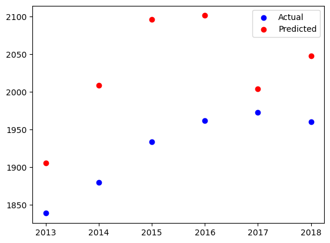

```python
CX_train, CY_train, CX_test, CY_test, Cpred ,Cname= suburb_data(Melbourne,'Melbourne')
model_svr('linear',CX_train, CX_test,CY_train, CY_test, Cpred, Cname)
```

```python
svr_parameters(CX_train, CY_train)
```

```
Best Parameters: {'C': 1.0, 'gamma': 0.0001, 'kernel': 'linear'}
Best score: -4.511793191777765
Best scorer: make_scorer(r2_score)
```

```python
elasticnet_parameters(CX_train, CY_train)
```

```
Fitting 5 folds for each of 42 candidates, totalling 210 fits
Best Parameters for Elastic Net: {'alpha': 100.0, 'l1_ratio': 0.74}
Best score for Elastic Net: 0.7867836062726552
```

```
Mean Suqared Error: 8311.74002154853
R-squared -2.4633853508929477
The predicted number of new cafe in Melbourne is [2211]
```

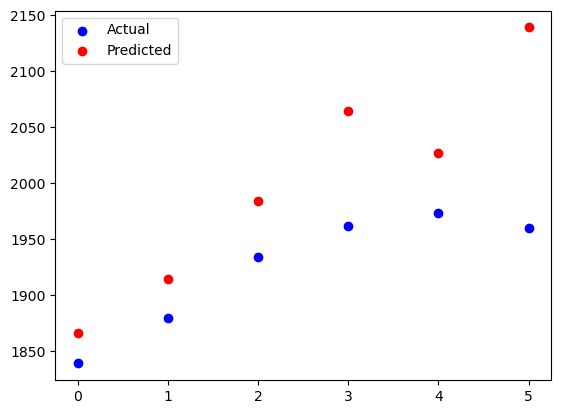

```python
model_elastic_best(100,0.74, CX_train, CX_test, CY_train, CY_test, Cpred, Cname)
```

```python
#### Carlton
```

```
Mean Suqared Error: 135.6658208394311
R-squared 0.6470100064889044
The predicted total number of cafe in Carlton is [407]
```

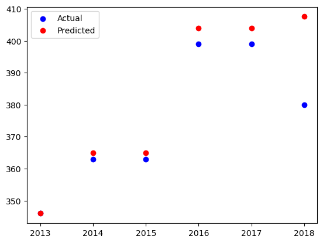

```python
X_train, Y_train, X_test, Y_test, pred ,name= suburb_data(Carlton,'Carlton')
model_svr('linear',X_train, X_test,Y_train, Y_test, pred, name)
```

```python
svr_parameters(X_train, Y_train)
```

```
Best Parameters: {'C': 1.0, 'gamma': 0.0001, 'kernel': 'linear'}
Best score: 0.10256546949309316
Best scorer: make_scorer(r2_score)
```

```python
elasticnet_parameters(X_train, Y_train)
```

```
Fitting 5 folds for each of 42 candidates, totalling 210 fits
Best Parameters for Elastic Net: {'alpha': 1.0, 'l1_ratio': 0.58}
Best score for Elastic Net: 0.24036283901450944
```

```
Mean Suqared Error: 61.13695634511248
R-squared 0.8409272601601583
The predicted number of new cafe in Carlton is [400]
```

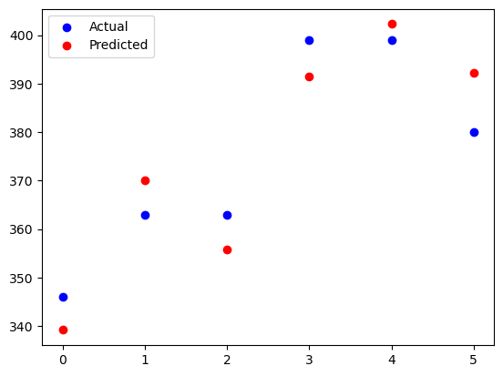

```python
model_elastic_best(10.0,0.99, X_train, X_test, Y_train, Y_test, pred, name)
```